# Assignement 1 (IDS) : Super Market Data Analytics

Introduction

A Supermarket is a self-service shop offering a wide variety of food, beverages and household products, organized into sections. The growth of supermarkets in most populated cities is increasing and market competitions are also high. The Super Market Sales Analytics is used to analyse the sales of different products in a supermarket located in different cities.

Objective

Follow the Data Science Methodology that we studied in Module 3. Analyse the data set and answer the following questions

Which city has a better sale for products in the Electronic Accessories product line.

Which payment method is used more often at a particular city, branch and for which product type

Which Product type has been more purchased by female customers

In which month does the highest number of home and lifestyle products have been sold

At what time most of the female customers are purchasing products.

This dataset contains various attributes of supermarkets like Invoice Id, Branch, City, Customer Type, Gender, Product Type, Unit Price, Quantity, Tax, Selling Price, Date, Time, Payment Type, Cost Price, Gross Income, Rating.

Tasks in this assignment

1) Write a Data Science Proposal for achieving the objective mentioned.

2) Perform exploratory analysis on the data and describe your understanding of the data.

3) Perform data wrangling / pre-processing a. E.g., missing data, normalization, discretization, etc.

4) Apply any two feature selection engineering techniques.

5) Compare the two selected feature engineering techniques.

7) Provide a high-level description of Machine Learning models – Logistic regression and Decision tree to predict.

8) Compare the performance of the two classifiers – Logistic regression and Decision tree to predict.

9) Present the conclusions/results (Answers to given objectives) in the format shared. Expected Submissions

One file is expected as the assignment submission.

The executed ipynb file with clear subdivision of the codes and brief description of the purpose of respective code. All the executed tables or graphs and results should be present in the ipynb file. The ipynb file maybe submitted as a single .pdf file or .html file

## Objective

```python
#Need to import the required packages
import pandas as pd
import numpy as np
import seaborn as sns
import matplotlib.pyplot as plt
%matplotlib inline
import warnings
```

```python
supermarket_data=pd.read_csv("Supermarket_Sales_Dataset.csv")
supermarket_data.head(2)
```

|  | Invoice ID | Branch | City | Customer Type | Gender | Product Type | Unit Price | Quantity | Tax | Selling Price | Date | Time | Payment Type | Cost Price | Gross Income | Rating |
| --- | --- | --- | --- | --- | --- | --- | --- | --- | --- | --- | --- | --- | --- | --- | --- | --- |
| 0 | 750-67-8428 | A | Bangalore | Member | Female | Health and beauty | 74.69 | 7 | 26.1415 | 548.9715 | 1/5/2019 | 13:08 | Debit card | 522.83 | 26.1415 | 9.1 |
| 1 | 226-31-3081 | C | Mysore | Normal | Female | Electronic accessories | 15.28 | 5 | 3.8200 | 80.2200 | 3/8/2019 | 10:29 | Cash | 76.40 | 3.8200 | 9.6 |

```python
supermarket_data.shape
```

```
(1000, 16)
```

```python
supermarket_data.columns
```

```
Index(['Invoice ID', 'Branch', 'City', 'Customer Type', 'Gender',
       'Product Type', 'Unit Price', 'Quantity', 'Tax ', 'Selling Price',
       'Date', 'Time', 'Payment Type', 'Cost Price', 'Gross Income', 'Rating'],
      dtype='object')
```

```python
print(supermarket_data['City'].unique())
```

```
['Bangalore' 'Mysore' 'Mangalore']
```

```python
print(supermarket_data['City'].unique())
print(supermarket_data['Product Type'].unique())
print(supermarket_data['Customer Type'].unique())
print(supermarket_data['Gender'].unique())
print(supermarket_data['Payment Type'].unique())
```

```
['Bangalore' 'Mysore' 'Mangalore']
['Health and beauty' 'Electronic accessories' 'Home and lifestyle'
 'Sports and travel' 'Food and beverages' 'Fashion accessories']
['Member' 'Normal']
['Female' 'Male']
['Debit card' 'Cash' 'Credit card']
```

```python
supermarket_data.describe
```

```
<bound method NDFrame.describe of       Invoice ID Branch       City Customer Type  Gender  \
0    750-67-8428      A  Bangalore        Member  Female
1    226-31-3081      C     Mysore        Normal  Female
2    631-41-3108      A  Bangalore        Normal    Male
3    123-19-1176      A  Bangalore        Member    Male
4    373-73-7910      A  Bangalore        Normal    Male
5    699-14-3026      C     Mysore        Normal    Male
6    355-53-5943      A  Bangalore        Member  Female
7    315-22-5665      C     Mysore        Normal  Female
8    665-32-9167      A  Bangalore        Member  Female
9    692-92-5582      B  Mangalore        Member  Female
10   351-62-0822      B  Mangalore        Member  Female
11   529-56-3974      B  Mangalore        Member    Male
12   365-64-0515      A  Bangalore        Normal  Female
13   252-56-2699      A  Bangalore        Normal    Male
```

[output cut: 175 more lines]

# Creating a data frame from the super market data set

```python
supermarket_df = pd.DataFrame()
supermarket_df['InvoiceID'] = supermarket_data['Invoice ID']
supermarket_df['Branch'] = supermarket_data['Branch']
supermarket_df['City'] = supermarket_data['City']
supermarket_df['Gender'] = supermarket_data['Gender']
supermarket_df['CustomerType']=supermarket_data['Customer Type']
supermarket_df['ProductType'] = supermarket_data['Product Type']
supermarket_df['UnitPrice'] = supermarket_data['Unit Price']
supermarket_df['Quantity'] = supermarket_data['Quantity']
supermarket_df['SellingPrice'] = supermarket_data['Selling Price']
supermarket_df['Date'] = supermarket_data['Date']
supermarket_df['Time'] = supermarket_data['Time']
supermarket_df['PaymentType'] = supermarket_data['Payment Type']
supermarket_df['Rating'] = supermarket_data['Rating']
supermarket_df.head(2)
```

|  | InvoiceID | Branch | City | Gender | CustomerType | ProductType | UnitPrice | Quantity | SellingPrice | Date | Time | PaymentType | Rating |
| --- | --- | --- | --- | --- | --- | --- | --- | --- | --- | --- | --- | --- | --- |
| 0 | 750-67-8428 | A | Bangalore | Female | Member | Health and beauty | 74.69 | 7 | 548.9715 | 1/5/2019 | 13:08 | Debit card | 9.1 |
| 1 | 226-31-3081 | C | Mysore | Female | Normal | Electronic accessories | 15.28 | 5 | 80.2200 | 3/8/2019 | 10:29 | Cash | 9.6 |

```python
supermarket_df.info()
```

```
<class 'pandas.core.frame.DataFrame'>
RangeIndex: 1000 entries, 0 to 999
Data columns (total 13 columns):
InvoiceID       1000 non-null object
Branch          1000 non-null object
City            1000 non-null object
Gender          1000 non-null object
CustomerType    1000 non-null object
ProductType     1000 non-null object
UnitPrice       1000 non-null float64
Quantity        1000 non-null int64
SellingPrice    1000 non-null float64
Date            1000 non-null object
Time            1000 non-null object
PaymentType     1000 non-null object
Rating          1000 non-null float64
dtypes: float64(3), int64(1), object(9)
memory usage: 101.6+ KB
```

To find the city in which products of type "Electronic accessories" have been sold most, let's create a pivot table between city, product type and sum of quantity

```python
pivot = supermarket_df.where(supermarket_df.ProductType =='Electronic accessories').pivot_table(
    index=['City'],
    columns=['ProductType'],
    values='Quantity',
    aggfunc='sum'
)
pivot
```

| ProductType City | Electronic accessories |
| --- | --- |
| Bangalore | 322.0 |
| Mangalore | 316.0 |
| Mysore | 333.0 |

So, based on above Pivot, we see in the city of Mysore, products of electronic accessories have been sold more compared to other 2 cities

To find which payment method is used more often at a particular city, branch and for which product type, lets create a pivot between city, product type and payment type

```python
pivot1 = pd.pivot_table(
    data=supermarket_df,
    index=['City','ProductType'],
    columns='PaymentType',
    values='InvoiceID',
    aggfunc='count'
)
pivot1
```

| City | PaymentType ProductType | Cash | Credit card | Debit card |
| --- | --- | --- | --- | --- |
| Bangalore | Electronic accessories | 18 | 21 | 21 |
|  | Fashion accessories | 13 | 17 | 21 |
|  | Food and beverages | 18 | 21 | 19 |
|  | Health and beauty | 17 | 14 | 16 |
|  | Home and lifestyle | 24 | 15 | 26 |
|  | Sports and travel | 20 | 16 | 23 |
| Mangalore | Electronic accessories | 24 | 15 | 16 |
|  | Fashion accessories | 22 | 19 | 21 |
|  | Food and beverages | 8 | 25 | 17 |
|  | Health and beauty | 17 | 17 | 19 |
|  | Home and lifestyle | 13 | 15 | 22 |
|  | Sports and travel | 26 | 18 | 18 |
| Mysore | Electronic accessories | 29 | 10 | 16 |
|  | Fashion accessories | 22 | 20 | 23 |
|  | Food and beverages | 31 | 15 | 20 |
|  | Health and beauty | 15 | 19 | 18 |
|  | Home and lifestyle | 14 | 15 | 16 |
|  | Sports and travel | 13 | 19 | 13 |

Based on the above pivot, For the city of Bangalore, we can see Credit card and debit card are used more for electronic accessaories and whereas for debit card is used more in buying fashion accessories in bangalore. Customers used credit card more while spending on food and beverages, but when it comes to Health and beauty, they preferred to pay in cash. For Home and life style along with Sports and travel, they paid maximum times using debit card.

Similarly we can derive the payment methods for each product type and rest of the 2 city from the above pivot easily.

```python
pivot5 = supermarket_df.where(supermarket_df['Gender'] =='Female').pivot_table(
    index=['ProductType'],
    values='Quantity',
    aggfunc='sum'
)
pivot5
```

| ProductType | Quantity |
| --- | --- |
| Electronic accessories | 488.0 |
| Fashion accessories | 530.0 |
| Food and beverages | 514.0 |
| Health and beauty | 343.0 |
| Home and lifestyle | 498.0 |
| Sports and travel | 496.0 |

Based on the above pivot, it is quite evident that Females have purchased more of the "Fashion Accessories" overall across all cities based on the volume (quantity).

```python
pivot6 = supermarket_df.where(supermarket_df['Gender'] =='Female').pivot_table(
    index=['ProductType'],
    values='SellingPrice',
    aggfunc='sum'
)
pivot6
```

| ProductType | SellingPrice |
| --- | --- |
| Electronic accessories | 27102.0225 |
| Fashion accessories | 30437.4000 |
| Food and beverages | 33170.9175 |
| Health and beauty | 18560.9865 |
| Home and lifestyle | 30036.8775 |
| Sports and travel | 28574.7210 |

Based on the money spent across different product type, it seems female have spent more on Food and beverages.

```python
pivot7 = supermarket_df.where(supermarket_df['Gender'] =='Female').pivot_table(
    index=['ProductType'],
    values='InvoiceID',
    aggfunc='count'
)
pivot7
```

| ProductType | InvoiceID |
| --- | --- |
| Electronic accessories | 84 |
| Fashion accessories | 96 |
| Food and beverages | 90 |
| Health and beauty | 64 |
| Home and lifestyle | 79 |
| Sports and travel | 88 |

Based on the above pivot, Females have placed maximum orders in the segment "Fashion and Acessories"

Now, let's convert the data type of Date from object to datatime format for the ease of calculation.

```python
supermarket_df['Date'] = pd.to_datetime(supermarket_df['Date'])
```

```python
supermarket_df['day'] = (supermarket_df['Date']).dt.day
supermarket_df['month'] = (supermarket_df['Date']).dt.month
supermarket_df['year'] = (supermarket_df['Date']).dt.year
```

Now the ask is to find which month was the highest number of home and lifestyle products have been sold. To find that let's create a pivot between Month and Sum of quantity where the product type is Home and Life style.

```python
pivot2 = supermarket_df.where(supermarket_df.ProductType =='Home and lifestyle').pivot_table(
    index= 'month',
    values='Quantity',
    aggfunc='sum'
)
pivot2
```

| month | Quantity |
| --- | --- |
| 1.0 | 342.0 |
| 2.0 | 205.0 |
| 3.0 | 364.0 |

From the above pivot, it is clear that in the month of March, the sale of product type Home and Life style is more than January and February.

```python
supermarket_df.shape
```

```
(1000, 16)
```

Now, lets try to create bins out of the Time column so that we can categorize the time period in which sales are more.

```python
supermarket_df['Time'] = pd.to_datetime(supermarket_df['Time'])
```

```python
min_value = supermarket_df['Time'].min()
max_value = supermarket_df['Time'].max()
print(min_value)
print(max_value)
```

```
2022-11-22 10:00:00
2022-11-22 20:59:00
```

```python
bins = [0, 6, 12, 18, 24]
labels = ['Night', 'Morning', 'Afternoon', 'Evening']
```

```python
supermarket_df['TimeBin'] = pd.cut(supermarket_df.Time.dt.hour, bins, labels=labels, right=False)
```

The ask is to find out when do the Female customers purchase more during the day. So, let's use the "TimeBin" column and create a pivot against Sum of quantity for the Female Gender.

```python
pivot = supermarket_df.where(supermarket_df.Gender =='Female').pivot_table(
    index=['TimeBin'],
    values='Quantity',
    aggfunc='sum'
)
pivot
```

| TimeBin | Quantity |
| --- | --- |
| Night | 0.0 |
| Morning | 604.0 |
| Afternoon | 1552.0 |
| Evening | 713.0 |

Based on the above pivot, it seems the female customers mostly purchase in the afternoon time between (12PM to 6PM) compared to any other time during the day.

```python
supermarket_df.head()
```

|  | InvoiceID | Branch | City | Gender | CustomerType | ProductType | UnitPrice | Quantity | SellingPrice | Date | Time | PaymentType | Rating | day | month | year | TimeBin |
| --- | --- | --- | --- | --- | --- | --- | --- | --- | --- | --- | --- | --- | --- | --- | --- | --- | --- |
| 0 | 750-67-8428 | A | Bangalore | Female | Member | Health and beauty | 74.69 | 7 | 548.9715 | 2019-01-05 | 2022-11-22 13:08:00 | Debit card | 9.1 | 5 | 1 | 2019 | Afternoon |
| 1 | 226-31-3081 | C | Mysore | Female | Normal | Electronic accessories | 15.28 | 5 | 80.2200 | 2019-03-08 | 2022-11-22 10:29:00 | Cash | 9.6 | 8 | 3 | 2019 | Morning |
| 2 | 631-41-3108 | A | Bangalore | Male | Normal | Home and lifestyle | 46.33 | 7 | 340.5255 | 2019-03-03 | 2022-11-22 13:23:00 | Credit card | 7.4 | 3 | 3 | 2019 | Afternoon |
| 3 | 123-19-1176 | A | Bangalore | Male | Member | Health and beauty | 58.22 | 8 | 489.0480 | 2019-01-27 | 2022-11-22 20:33:00 | Debit card | 8.4 | 27 | 1 | 2019 | Evening |
| 4 | 373-73-7910 | A | Bangalore | Male | Normal | Sports and travel | 86.31 | 7 | 634.3785 | 2019-02-08 | 2022-11-22 10:37:00 | Debit card | 5.3 | 8 | 2 | 2019 | Morning |

# Exploratory Data Analysis

```python
supermarket_data.isnull().sum()
```

```
Invoice ID       0
Branch           0
City             0
Customer Type    0
Gender           0
Product Type     0
Unit Price       0
Quantity         0
Tax              0
Selling Price    0
Date             0
Time             0
Payment Type     0
Cost Price       0
Gross Income     0
Rating           0
dtype: int64
```

```python
supermarket_df['Branch'].value_counts()
```

```
A    340
B    332
C    328
Name: Branch, dtype: int64
```

```python
# Set the color coding for the visualizations to be plotted
from matplotlib import cm
cmap = cm.get_cmap('jet')
cmap1 = cm.get_cmap('Spectral')
```

```python
supermarket_df['ProductType'].value_counts()
```

```
Fashion accessories       178
Food and beverages        174
Electronic accessories    170
Sports and travel         166
Home and lifestyle        160
Health and beauty         152
Name: ProductType, dtype: int64
```

```python
supermarket_df['PaymentType'].value_counts()
```

```
Debit card     345
Cash           344
Credit card    311
Name: PaymentType, dtype: int64
```

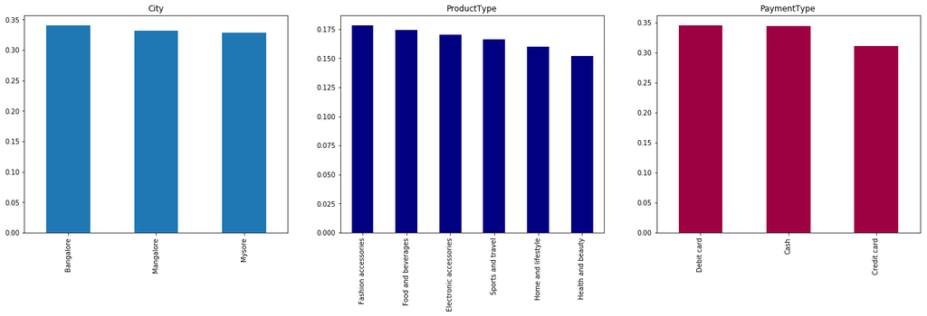

```python
#Prepare a layout two render these categorical attributes
import matplotlib.pyplot as plt
%matplotlib inline

plt.figure(1)

plt.subplot(131)
supermarket_df['City'].value_counts(normalize=True).plot.bar(figsize=(24,6), title= 'City')

plt.subplot(132)
supermarket_df['ProductType'].value_counts(normalize=True).plot.bar(title= 'ProductType', cmap=cmap)

plt.subplot(133)
supermarket_df['PaymentType'].value_counts(normalize=True).plot.bar(title= 'PaymentType', cmap=cmap1)

plt.show()
```

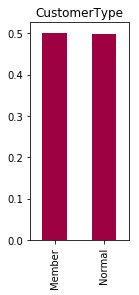

```python
plt.subplot(131)
supermarket_df['CustomerType'].value_counts(normalize=True).plot.bar(title= 'CustomerType', cmap=cmap1)
```

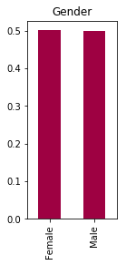

```python
plt.subplot(131)
supermarket_df['Gender'].value_counts(normalize=True).plot.bar(title= 'Gender', cmap=cmap1)
```

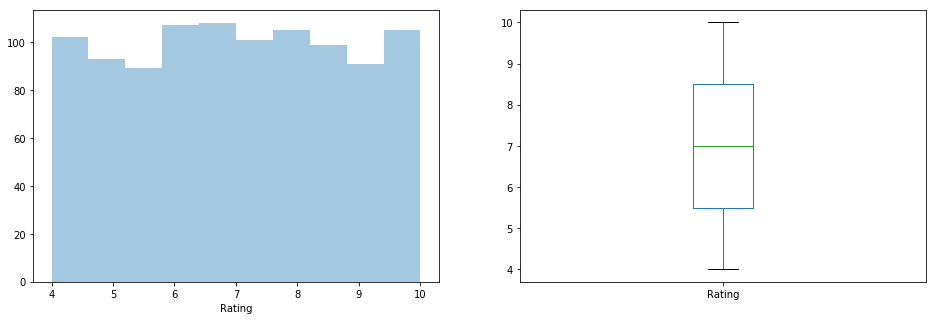

```python
plt.figure(1)
plt.subplot(121)
sns.distplot(supermarket_df['Rating'], hist=True, kde=False);


plt.subplot(122)
supermarket_df['Rating'].plot.box(figsize=(16,5))
plt.show()
```

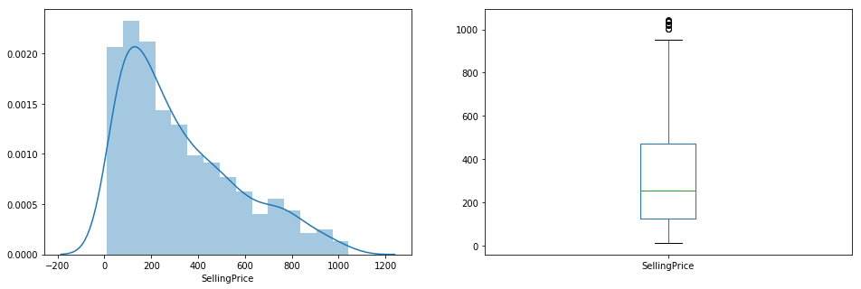

```python
plt.figure(1)
plt.subplot(121)
df=supermarket_df.dropna()
sns.distplot(supermarket_df['SellingPrice']);

plt.subplot(122)
supermarket_df['SellingPrice'].plot.box(figsize=(16,5))
plt.show()
```

## Bivariate Analysis

Let's try to create another target variable "Rating Type"

```python
min_value = supermarket_df['Rating'].min()
max_value = supermarket_df['Rating'].max()
print(min_value)
print(max_value)
```

```
4.0
10.0
```

```python
import numpy as np
bins1 = np.linspace(min_value,max_value,4)
bins1
```

```
array([ 4.,  6.,  8., 10.])
```

```python
labels = ['Average', 'Good','Excellent']
```

```python
supermarket_df['bins1'] = pd.cut(supermarket_df['Rating'], bins=bins1, labels=labels, include_lowest=True)
```

```python
supermarket_df
```

|  | InvoiceID | Branch | City | Gender | CustomerType | ProductType | UnitPrice | Quantity | SellingPrice | Date | Time | PaymentType | Rating | day | month | year | TimeBin | bins1 |
| --- | --- | --- | --- | --- | --- | --- | --- | --- | --- | --- | --- | --- | --- | --- | --- | --- | --- | --- |
| 0 | 750-67-8428 | A | Bangalore | Female | Member | Health and beauty | 74.69 | 7 | 548.9715 | 2019-01-05 | 2022-11-22 13:08:00 | Debit card | 9.1 | 5 | 1 | 2019 | Afternoon | Excellent |
| 1 | 226-31-3081 | C | Mysore | Female | Normal | Electronic accessories | 15.28 | 5 | 80.2200 | 2019-03-08 | 2022-11-22 10:29:00 | Cash | 9.6 | 8 | 3 | 2019 | Morning | Excellent |
| 2 | 631-41-3108 | A | Bangalore | Male | Normal | Home and lifestyle | 46.33 | 7 | 340.5255 | 2019-03-03 | 2022-11-22 13:23:00 | Credit card | 7.4 | 3 | 3 | 2019 | Afternoon | Good |
| 3 | 123-19-1176 | A | Bangalore | Male | Member | Health and beauty | 58.22 | 8 | 489.0480 | 2019-01-27 | 2022-11-22 20:33:00 | Debit card | 8.4 | 27 | 1 | 2019 | Evening | Excellent |
| 4 | 373-73-7910 | A | Bangalore | Male | Normal | Sports and travel | 86.31 | 7 | 634.3785 | 2019-02-08 | 2022-11-22 10:37:00 | Debit card | 5.3 | 8 | 2 | 2019 | Morning | Average |
| 5 | 699-14-3026 | C | Mysore | Male | Normal | Electronic accessories | 85.39 | 7 | 627.6165 | 2019-03-25 | 2022-11-22 18:30:00 | Debit card | 4.1 | 25 | 3 | 2019 | Evening | Average |
| 6 | 355-53-5943 | A | Bangalore | Female | Member | Electronic accessories | 68.84 | 6 | 433.6920 | 2019-02-25 | 2022-11-22 14:36:00 | Debit card | 5.8 | 25 | 2 | 2019 | Afternoon | Average |
| 7 | 315-22-5665 | C | Mysore | Female | Normal | Home and lifestyle | 73.56 | 10 | 772.3800 | 2019-02-24 | 2022-11-22 11:38:00 | Debit card | 8.0 | 24 | 2 | 2019 | Morning | Good |
| 8 | 665-32-9167 | A | Bangalore | Female | Member | Health and beauty | 36.26 | 2 | 76.1460 | 2019-01-10 | 2022-11-22 17:15:00 | Credit card | 7.2 | 10 | 1 | 2019 | Afternoon | Good |
| 9 | 692-92-5582 | B | Mangalore | Female | Member | Food and beverages | 54.84 | 3 | 172.7460 | 2019-02-20 | 2022-11-22 13:27:00 | Credit card | 5.9 | 20 | 2 | 2019 | Afternoon | Average |
| 10 | 351-62-0822 | B | Mangalore | Female | Member | Fashion accessories | 14.48 | 4 | 60.8160 | 2019-02-06 | 2022-11-22 18:07:00 | Debit card | 4.5 | 6 | 2 | 2019 | Evening | Average |
| 11 | 529-56-3974 | B | Mangalore | Male | Member | Electronic accessories | 25.51 | 4 | 107.1420 | 2019-03-09 | 2022-11-22 17:03:00 | Cash | 6.8 | 9 | 3 | 2019 | Afternoon | Good |
| 12 | 365-64-0515 | A | Bangalore | Female | Normal | Electronic accessories | 46.95 | 5 | 246.4875 | 2019-02-12 | 2022-11-22 10:25:00 | Debit card | 7.1 | 12 | 2 | 2019 | Morning | Good |
| 13 | 252-56-2699 | A | Bangalore | Male | Normal | Food and beverages | 43.19 | 10 | 453.4950 | 2019-02-07 | 2022-11-22 16:48:00 | Debit card | 8.2 | 7 | 2 | 2019 | Afternoon | Excellent |
| 14 | 829-34-3910 | A | Bangalore | Female | Normal | Health and beauty | 71.38 | 10 | 749.4900 | 2019-03-29 | 2022-11-22 19:21:00 | Cash | 5.7 | 29 | 3 | 2019 | Evening | Average |
| 15 | 299-46-1805 | B | Mangalore | Female | Member | Sports and travel | 93.72 | 6 | 590.4360 | 2019-01-15 | 2022-11-22 16:19:00 | Cash | 4.5 | 15 | 1 | 2019 | Afternoon | Average |
| 16 | 656-95-9349 | A | Bangalore | Female | Member | Health and beauty | 68.93 | 7 | 506.6355 | 2019-03-11 | 2022-11-22 11:03:00 | Credit card | 4.6 | 11 | 3 | 2019 | Morning | Average |
| 17 | 765-26-6951 | A | Bangalore | Male | Normal | Sports and travel | 72.61 | 6 | 457.4430 | 2019-01-01 | 2022-11-22 10:39:00 | Credit card | 6.9 | 1 | 1 | 2019 | Morning | Good |
| 18 | 329-62-1586 | A | Bangalore | Male | Normal | Food and beverages | 54.67 | 3 | 172.2105 | 2019-01-21 | 2022-11-22 18:00:00 | Credit card | 8.6 | 21 | 1 | 2019 | Evening | Excellent |
| 19 | 319-50-3348 | B | Mangalore | Female | Normal | Home and lifestyle | 40.30 | 2 | 84.6300 | 2019-03-11 | 2022-11-22 15:30:00 | Debit card | 4.4 | 11 | 3 | 2019 | Afternoon | Average |
| 20 | 300-71-4605 | C | Mysore | Male | Member | Electronic accessories | 86.04 | 5 | 451.7100 | 2019-02-25 | 2022-11-22 11:24:00 | Debit card | 4.8 | 25 | 2 | 2019 | Morning | Average |
| 21 | 371-85-5789 | B | Mangalore | Male | Normal | Health and beauty | 87.98 | 3 | 277.1370 | 2019-03-05 | 2022-11-22 10:40:00 | Debit card | 5.1 | 5 | 3 | 2019 | Morning | Average |
| 22 | 273-16-6619 | B | Mangalore | Male | Normal | Home and lifestyle | 33.20 | 2 | 69.7200 | 2019-03-15 | 2022-11-22 12:20:00 | Credit card | 4.4 | 15 | 3 | 2019 | Afternoon | Average |
| 23 | 636-48-8204 | A | Bangalore | Male | Normal | Electronic accessories | 34.56 | 5 | 181.4400 | 2019-02-17 | 2022-11-22 11:15:00 | Debit card | 9.9 | 17 | 2 | 2019 | Morning | Excellent |
| 24 | 549-59-1358 | A | Bangalore | Male | Member | Sports and travel | 88.63 | 3 | 279.1845 | 2019-03-02 | 2022-11-22 17:36:00 | Debit card | 6.0 | 2 | 3 | 2019 | Afternoon | Average |
| 25 | 227-03-5010 | A | Bangalore | Female | Member | Home and lifestyle | 52.59 | 8 | 441.7560 | 2019-03-22 | 2022-11-22 19:20:00 | Credit card | 8.5 | 22 | 3 | 2019 | Evening | Excellent |
| 26 | 649-29-6775 | B | Mangalore | Male | Normal | Fashion accessories | 33.52 | 1 | 35.1960 | 2019-02-08 | 2022-11-22 15:31:00 | Cash | 6.7 | 8 | 2 | 2019 | Afternoon | Good |
| 27 | 189-17-4241 | A | Bangalore | Female | Normal | Fashion accessories | 87.67 | 2 | 184.1070 | 2019-03-10 | 2022-11-22 12:17:00 | Credit card | 7.7 | 10 | 3 | 2019 | Afternoon | Good |
| 28 | 145-94-9061 | B | Mangalore | Female | Normal | Food and beverages | 88.36 | 5 | 463.8900 | 2019-01-25 | 2022-11-22 19:48:00 | Cash | 9.6 | 25 | 1 | 2019 | Evening | Excellent |
| 29 | 848-62-7243 | A | Bangalore | Male | Normal | Health and beauty | 24.89 | 9 | 235.2105 | 2019-03-15 | 2022-11-22 15:36:00 | Cash | 7.4 | 15 | 3 | 2019 | Afternoon | Good |
| ... | ... | ... | ... | ... | ... | ... | ... | ... | ... | ... | ... | ... | ... | ... | ... | ... | ... | ... |
| 970 | 746-04-1077 | B | Mangalore | Female | Member | Food and beverages | 84.63 | 10 | 888.6150 | 2019-01-01 | 2022-11-22 11:36:00 | Credit card | 9.0 | 1 | 1 | 2019 | Morning | Excellent |
| 971 | 448-34-8700 | B | Mangalore | Male | Member | Home and lifestyle | 36.91 | 7 | 271.2885 | 2019-02-10 | 2022-11-22 13:51:00 | Debit card | 6.7 | 10 | 2 | 2019 | Afternoon | Good |
| 972 | 452-04-8808 | B | Mangalore | Male | Normal | Electronic accessories | 87.08 | 7 | 640.0380 | 2019-01-26 | 2022-11-22 15:17:00 | Cash | 5.5 | 26 | 1 | 2019 | Afternoon | Average |
| 973 | 531-56-4728 | A | Bangalore | Male | Normal | Home and lifestyle | 80.08 | 3 | 252.2520 | 2019-02-11 | 2022-11-22 15:29:00 | Cash | 5.4 | 11 | 2 | 2019 | Afternoon | Average |
| 974 | 744-82-9138 | C | Mysore | Male | Normal | Fashion accessories | 86.13 | 2 | 180.8730 | 2019-02-07 | 2022-11-22 17:59:00 | Cash | 8.2 | 7 | 2 | 2019 | Afternoon | Excellent |
| 975 | 883-69-1285 | B | Mangalore | Male | Member | Fashion accessories | 49.92 | 2 | 104.8320 | 2019-03-06 | 2022-11-22 11:55:00 | Credit card | 7.0 | 6 | 3 | 2019 | Morning | Good |
| 976 | 221-25-5073 | A | Bangalore | Female | Normal | Food and beverages | 74.66 | 4 | 313.5720 | 2019-03-04 | 2022-11-22 10:39:00 | Cash | 8.5 | 4 | 3 | 2019 | Morning | Excellent |
| 977 | 518-71-6847 | B | Mangalore | Male | Member | Food and beverages | 26.60 | 6 | 167.5800 | 2019-02-26 | 2022-11-22 15:10:00 | Debit card | 4.9 | 26 | 2 | 2019 | Afternoon | Average |
| 978 | 156-20-0370 | B | Mangalore | Female | Normal | Electronic accessories | 25.45 | 1 | 26.7225 | 2019-03-10 | 2022-11-22 18:10:00 | Credit card | 5.1 | 10 | 3 | 2019 | Evening | Average |
| 979 | 151-33-7434 | B | Mangalore | Female | Normal | Food and beverages | 67.77 | 1 | 71.1585 | 2019-02-04 | 2022-11-22 20:43:00 | Credit card | 6.5 | 4 | 2 | 2019 | Evening | Good |
| 980 | 728-47-9078 | C | Mysore | Male | Member | Food and beverages | 59.59 | 4 | 250.2780 | 2019-01-19 | 2022-11-22 12:46:00 | Cash | 9.8 | 19 | 1 | 2019 | Afternoon | Excellent |
| 981 | 809-46-1866 | A | Bangalore | Male | Normal | Health and beauty | 58.15 | 4 | 244.2300 | 2019-01-23 | 2022-11-22 17:44:00 | Cash | 8.4 | 23 | 1 | 2019 | Afternoon | Excellent |
| 982 | 139-32-4183 | A | Bangalore | Female | Member | Sports and travel | 97.48 | 9 | 921.1860 | 2019-03-14 | 2022-11-22 14:19:00 | Debit card | 7.4 | 14 | 3 | 2019 | Afternoon | Good |
| 983 | 148-41-7930 | C | Mysore | Male | Normal | Health and beauty | 99.96 | 7 | 734.7060 | 2019-01-23 | 2022-11-22 10:33:00 | Cash | 6.1 | 23 | 1 | 2019 | Morning | Good |
| 984 | 189-40-5216 | C | Mysore | Male | Normal | Electronic accessories | 96.37 | 7 | 708.3195 | 2019-01-09 | 2022-11-22 11:40:00 | Cash | 6.0 | 9 | 1 | 2019 | Morning | Average |
| 985 | 374-38-5555 | B | Mangalore | Female | Normal | Fashion accessories | 63.71 | 5 | 334.4775 | 2019-02-07 | 2022-11-22 19:30:00 | Debit card | 8.5 | 7 | 2 | 2019 | Evening | Excellent |
| 986 | 764-44-8999 | B | Mangalore | Female | Normal | Health and beauty | 14.76 | 2 | 30.9960 | 2019-02-18 | 2022-11-22 14:42:00 | Debit card | 4.3 | 18 | 2 | 2019 | Afternoon | Average |
| 987 | 552-44-5977 | B | Mangalore | Male | Member | Health and beauty | 62.00 | 8 | 520.8000 | 2019-01-03 | 2022-11-22 19:08:00 | Credit card | 6.2 | 3 | 1 | 2019 | Evening | Good |
| 988 | 267-62-7380 | C | Mysore | Male | Member | Electronic accessories | 82.34 | 10 | 864.5700 | 2019-03-29 | 2022-11-22 19:12:00 | Debit card | 4.3 | 29 | 3 | 2019 | Evening | Average |
| 989 | 430-53-4718 | B | Mangalore | Male | Member | Health and beauty | 75.37 | 8 | 633.1080 | 2019-01-28 | 2022-11-22 15:46:00 | Credit card | 8.4 | 28 | 1 | 2019 | Afternoon | Excellent |
| 990 | 886-18-2897 | A | Bangalore | Female | Normal | Food and beverages | 56.56 | 5 | 296.9400 | 2019-03-22 | 2022-11-22 19:06:00 | Credit card | 4.5 | 22 | 3 | 2019 | Evening | Average |
| 991 | 602-16-6955 | B | Mangalore | Female | Normal | Sports and travel | 76.60 | 10 | 804.3000 | 2019-01-24 | 2022-11-22 18:10:00 | Debit card | 6.0 | 24 | 1 | 2019 | Evening | Average |
| 992 | 745-74-0715 | A | Bangalore | Male | Normal | Electronic accessories | 58.03 | 2 | 121.8630 | 2019-03-10 | 2022-11-22 20:46:00 | Debit card | 8.8 | 10 | 3 | 2019 | Evening | Excellent |
| 993 | 690-01-6631 | B | Mangalore | Male | Normal | Fashion accessories | 17.49 | 10 | 183.6450 | 2019-02-22 | 2022-11-22 18:35:00 | Debit card | 6.6 | 22 | 2 | 2019 | Evening | Good |
| 994 | 652-49-6720 | C | Mysore | Female | Member | Electronic accessories | 60.95 | 1 | 63.9975 | 2019-02-18 | 2022-11-22 11:40:00 | Debit card | 5.9 | 18 | 2 | 2019 | Morning | Average |
| 995 | 233-67-5758 | C | Mysore | Male | Normal | Health and beauty | 40.35 | 1 | 42.3675 | 2019-01-29 | 2022-11-22 13:46:00 | Debit card | 6.2 | 29 | 1 | 2019 | Afternoon | Good |
| 996 | 303-96-2227 | B | Mangalore | Female | Normal | Home and lifestyle | 97.38 | 10 | 1022.4900 | 2019-03-02 | 2022-11-22 17:16:00 | Debit card | 4.4 | 2 | 3 | 2019 | Afternoon | Average |
| 997 | 727-02-1313 | A | Bangalore | Male | Member | Food and beverages | 31.84 | 1 | 33.4320 | 2019-02-09 | 2022-11-22 13:22:00 | Cash | 7.7 | 9 | 2 | 2019 | Afternoon | Good |
| 998 | 347-56-2442 | A | Bangalore | Male | Normal | Home and lifestyle | 65.82 | 1 | 69.1110 | 2019-02-22 | 2022-11-22 15:33:00 | Cash | 4.1 | 22 | 2 | 2019 | Afternoon | Average |
| 999 | 849-09-3807 | A | Bangalore | Female | Member | Fashion accessories | 88.34 | 7 | 649.2990 | 2019-02-18 | 2022-11-22 13:28:00 | Cash | 6.6 | 18 | 2 | 2019 | Afternoon | Good |

1000 rows × 18 columns

```python
supermarket_df = supermarket_df.rename(columns = {'bins1':'RatingType'})
```

```python
supermarket_df.head()
```

|  | InvoiceID | Branch | City | Gender | CustomerType | ProductType | UnitPrice | Quantity | SellingPrice | Date | Time | PaymentType | Rating | day | month | year | TimeBin | RatingType |
| --- | --- | --- | --- | --- | --- | --- | --- | --- | --- | --- | --- | --- | --- | --- | --- | --- | --- | --- |
| 0 | 750-67-8428 | A | Bangalore | Female | Member | Health and beauty | 74.69 | 7 | 548.9715 | 2019-01-05 | 2022-11-22 13:08:00 | Debit card | 9.1 | 5 | 1 | 2019 | Afternoon | Excellent |
| 1 | 226-31-3081 | C | Mysore | Female | Normal | Electronic accessories | 15.28 | 5 | 80.2200 | 2019-03-08 | 2022-11-22 10:29:00 | Cash | 9.6 | 8 | 3 | 2019 | Morning | Excellent |
| 2 | 631-41-3108 | A | Bangalore | Male | Normal | Home and lifestyle | 46.33 | 7 | 340.5255 | 2019-03-03 | 2022-11-22 13:23:00 | Credit card | 7.4 | 3 | 3 | 2019 | Afternoon | Good |
| 3 | 123-19-1176 | A | Bangalore | Male | Member | Health and beauty | 58.22 | 8 | 489.0480 | 2019-01-27 | 2022-11-22 20:33:00 | Debit card | 8.4 | 27 | 1 | 2019 | Evening | Excellent |
| 4 | 373-73-7910 | A | Bangalore | Male | Normal | Sports and travel | 86.31 | 7 | 634.3785 | 2019-02-08 | 2022-11-22 10:37:00 | Debit card | 5.3 | 8 | 2 | 2019 | Morning | Average |

```python
del supermarket_df['Rating']
```

```python
supermarket_df.head()
```

|  | InvoiceID | Branch | City | Gender | CustomerType | ProductType | UnitPrice | Quantity | SellingPrice | Date | Time | PaymentType | day | month | year | TimeBin | RatingType |
| --- | --- | --- | --- | --- | --- | --- | --- | --- | --- | --- | --- | --- | --- | --- | --- | --- | --- |
| 0 | 750-67-8428 | A | Bangalore | Female | Member | Health and beauty | 74.69 | 7 | 548.9715 | 2019-01-05 | 2022-11-22 13:08:00 | Debit card | 5 | 1 | 2019 | Afternoon | Excellent |
| 1 | 226-31-3081 | C | Mysore | Female | Normal | Electronic accessories | 15.28 | 5 | 80.2200 | 2019-03-08 | 2022-11-22 10:29:00 | Cash | 8 | 3 | 2019 | Morning | Excellent |
| 2 | 631-41-3108 | A | Bangalore | Male | Normal | Home and lifestyle | 46.33 | 7 | 340.5255 | 2019-03-03 | 2022-11-22 13:23:00 | Credit card | 3 | 3 | 2019 | Afternoon | Good |
| 3 | 123-19-1176 | A | Bangalore | Male | Member | Health and beauty | 58.22 | 8 | 489.0480 | 2019-01-27 | 2022-11-22 20:33:00 | Debit card | 27 | 1 | 2019 | Evening | Excellent |
| 4 | 373-73-7910 | A | Bangalore | Male | Normal | Sports and travel | 86.31 | 7 | 634.3785 | 2019-02-08 | 2022-11-22 10:37:00 | Debit card | 8 | 2 | 2019 | Morning | Average |

```
<function matplotlib.pyplot.show(*args, **kw)>
```

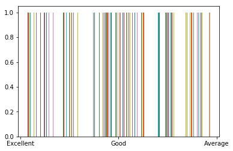

```python
import matplotlib.pyplot as plt
plt.hist(supermarket_df['RatingType'], bins=3)
plt.show
```

```python
supermarket_df
```

|  | InvoiceID | Branch | City | Gender | CustomerType | ProductType | UnitPrice | Quantity | SellingPrice | Date | Time | PaymentType | day | month | year | TimeBin | RatingType |
| --- | --- | --- | --- | --- | --- | --- | --- | --- | --- | --- | --- | --- | --- | --- | --- | --- | --- |
| 0 | 750-67-8428 | A | Bangalore | Female | Member | Health and beauty | 74.69 | 7 | 548.9715 | 2019-01-05 | 2022-11-22 13:08:00 | Debit card | 5 | 1 | 2019 | Afternoon | Excellent |
| 1 | 226-31-3081 | C | Mysore | Female | Normal | Electronic accessories | 15.28 | 5 | 80.2200 | 2019-03-08 | 2022-11-22 10:29:00 | Cash | 8 | 3 | 2019 | Morning | Excellent |
| 2 | 631-41-3108 | A | Bangalore | Male | Normal | Home and lifestyle | 46.33 | 7 | 340.5255 | 2019-03-03 | 2022-11-22 13:23:00 | Credit card | 3 | 3 | 2019 | Afternoon | Good |
| 3 | 123-19-1176 | A | Bangalore | Male | Member | Health and beauty | 58.22 | 8 | 489.0480 | 2019-01-27 | 2022-11-22 20:33:00 | Debit card | 27 | 1 | 2019 | Evening | Excellent |
| 4 | 373-73-7910 | A | Bangalore | Male | Normal | Sports and travel | 86.31 | 7 | 634.3785 | 2019-02-08 | 2022-11-22 10:37:00 | Debit card | 8 | 2 | 2019 | Morning | Average |
| 5 | 699-14-3026 | C | Mysore | Male | Normal | Electronic accessories | 85.39 | 7 | 627.6165 | 2019-03-25 | 2022-11-22 18:30:00 | Debit card | 25 | 3 | 2019 | Evening | Average |
| 6 | 355-53-5943 | A | Bangalore | Female | Member | Electronic accessories | 68.84 | 6 | 433.6920 | 2019-02-25 | 2022-11-22 14:36:00 | Debit card | 25 | 2 | 2019 | Afternoon | Average |
| 7 | 315-22-5665 | C | Mysore | Female | Normal | Home and lifestyle | 73.56 | 10 | 772.3800 | 2019-02-24 | 2022-11-22 11:38:00 | Debit card | 24 | 2 | 2019 | Morning | Good |
| 8 | 665-32-9167 | A | Bangalore | Female | Member | Health and beauty | 36.26 | 2 | 76.1460 | 2019-01-10 | 2022-11-22 17:15:00 | Credit card | 10 | 1 | 2019 | Afternoon | Good |
| 9 | 692-92-5582 | B | Mangalore | Female | Member | Food and beverages | 54.84 | 3 | 172.7460 | 2019-02-20 | 2022-11-22 13:27:00 | Credit card | 20 | 2 | 2019 | Afternoon | Average |
| 10 | 351-62-0822 | B | Mangalore | Female | Member | Fashion accessories | 14.48 | 4 | 60.8160 | 2019-02-06 | 2022-11-22 18:07:00 | Debit card | 6 | 2 | 2019 | Evening | Average |
| 11 | 529-56-3974 | B | Mangalore | Male | Member | Electronic accessories | 25.51 | 4 | 107.1420 | 2019-03-09 | 2022-11-22 17:03:00 | Cash | 9 | 3 | 2019 | Afternoon | Good |
| 12 | 365-64-0515 | A | Bangalore | Female | Normal | Electronic accessories | 46.95 | 5 | 246.4875 | 2019-02-12 | 2022-11-22 10:25:00 | Debit card | 12 | 2 | 2019 | Morning | Good |
| 13 | 252-56-2699 | A | Bangalore | Male | Normal | Food and beverages | 43.19 | 10 | 453.4950 | 2019-02-07 | 2022-11-22 16:48:00 | Debit card | 7 | 2 | 2019 | Afternoon | Excellent |
| 14 | 829-34-3910 | A | Bangalore | Female | Normal | Health and beauty | 71.38 | 10 | 749.4900 | 2019-03-29 | 2022-11-22 19:21:00 | Cash | 29 | 3 | 2019 | Evening | Average |
| 15 | 299-46-1805 | B | Mangalore | Female | Member | Sports and travel | 93.72 | 6 | 590.4360 | 2019-01-15 | 2022-11-22 16:19:00 | Cash | 15 | 1 | 2019 | Afternoon | Average |
| 16 | 656-95-9349 | A | Bangalore | Female | Member | Health and beauty | 68.93 | 7 | 506.6355 | 2019-03-11 | 2022-11-22 11:03:00 | Credit card | 11 | 3 | 2019 | Morning | Average |
| 17 | 765-26-6951 | A | Bangalore | Male | Normal | Sports and travel | 72.61 | 6 | 457.4430 | 2019-01-01 | 2022-11-22 10:39:00 | Credit card | 1 | 1 | 2019 | Morning | Good |
| 18 | 329-62-1586 | A | Bangalore | Male | Normal | Food and beverages | 54.67 | 3 | 172.2105 | 2019-01-21 | 2022-11-22 18:00:00 | Credit card | 21 | 1 | 2019 | Evening | Excellent |
| 19 | 319-50-3348 | B | Mangalore | Female | Normal | Home and lifestyle | 40.30 | 2 | 84.6300 | 2019-03-11 | 2022-11-22 15:30:00 | Debit card | 11 | 3 | 2019 | Afternoon | Average |
| 20 | 300-71-4605 | C | Mysore | Male | Member | Electronic accessories | 86.04 | 5 | 451.7100 | 2019-02-25 | 2022-11-22 11:24:00 | Debit card | 25 | 2 | 2019 | Morning | Average |
| 21 | 371-85-5789 | B | Mangalore | Male | Normal | Health and beauty | 87.98 | 3 | 277.1370 | 2019-03-05 | 2022-11-22 10:40:00 | Debit card | 5 | 3 | 2019 | Morning | Average |
| 22 | 273-16-6619 | B | Mangalore | Male | Normal | Home and lifestyle | 33.20 | 2 | 69.7200 | 2019-03-15 | 2022-11-22 12:20:00 | Credit card | 15 | 3 | 2019 | Afternoon | Average |
| 23 | 636-48-8204 | A | Bangalore | Male | Normal | Electronic accessories | 34.56 | 5 | 181.4400 | 2019-02-17 | 2022-11-22 11:15:00 | Debit card | 17 | 2 | 2019 | Morning | Excellent |
| 24 | 549-59-1358 | A | Bangalore | Male | Member | Sports and travel | 88.63 | 3 | 279.1845 | 2019-03-02 | 2022-11-22 17:36:00 | Debit card | 2 | 3 | 2019 | Afternoon | Average |
| 25 | 227-03-5010 | A | Bangalore | Female | Member | Home and lifestyle | 52.59 | 8 | 441.7560 | 2019-03-22 | 2022-11-22 19:20:00 | Credit card | 22 | 3 | 2019 | Evening | Excellent |
| 26 | 649-29-6775 | B | Mangalore | Male | Normal | Fashion accessories | 33.52 | 1 | 35.1960 | 2019-02-08 | 2022-11-22 15:31:00 | Cash | 8 | 2 | 2019 | Afternoon | Good |
| 27 | 189-17-4241 | A | Bangalore | Female | Normal | Fashion accessories | 87.67 | 2 | 184.1070 | 2019-03-10 | 2022-11-22 12:17:00 | Credit card | 10 | 3 | 2019 | Afternoon | Good |
| 28 | 145-94-9061 | B | Mangalore | Female | Normal | Food and beverages | 88.36 | 5 | 463.8900 | 2019-01-25 | 2022-11-22 19:48:00 | Cash | 25 | 1 | 2019 | Evening | Excellent |
| 29 | 848-62-7243 | A | Bangalore | Male | Normal | Health and beauty | 24.89 | 9 | 235.2105 | 2019-03-15 | 2022-11-22 15:36:00 | Cash | 15 | 3 | 2019 | Afternoon | Good |
| ... | ... | ... | ... | ... | ... | ... | ... | ... | ... | ... | ... | ... | ... | ... | ... | ... | ... |
| 970 | 746-04-1077 | B | Mangalore | Female | Member | Food and beverages | 84.63 | 10 | 888.6150 | 2019-01-01 | 2022-11-22 11:36:00 | Credit card | 1 | 1 | 2019 | Morning | Excellent |
| 971 | 448-34-8700 | B | Mangalore | Male | Member | Home and lifestyle | 36.91 | 7 | 271.2885 | 2019-02-10 | 2022-11-22 13:51:00 | Debit card | 10 | 2 | 2019 | Afternoon | Good |
| 972 | 452-04-8808 | B | Mangalore | Male | Normal | Electronic accessories | 87.08 | 7 | 640.0380 | 2019-01-26 | 2022-11-22 15:17:00 | Cash | 26 | 1 | 2019 | Afternoon | Average |
| 973 | 531-56-4728 | A | Bangalore | Male | Normal | Home and lifestyle | 80.08 | 3 | 252.2520 | 2019-02-11 | 2022-11-22 15:29:00 | Cash | 11 | 2 | 2019 | Afternoon | Average |
| 974 | 744-82-9138 | C | Mysore | Male | Normal | Fashion accessories | 86.13 | 2 | 180.8730 | 2019-02-07 | 2022-11-22 17:59:00 | Cash | 7 | 2 | 2019 | Afternoon | Excellent |
| 975 | 883-69-1285 | B | Mangalore | Male | Member | Fashion accessories | 49.92 | 2 | 104.8320 | 2019-03-06 | 2022-11-22 11:55:00 | Credit card | 6 | 3 | 2019 | Morning | Good |
| 976 | 221-25-5073 | A | Bangalore | Female | Normal | Food and beverages | 74.66 | 4 | 313.5720 | 2019-03-04 | 2022-11-22 10:39:00 | Cash | 4 | 3 | 2019 | Morning | Excellent |
| 977 | 518-71-6847 | B | Mangalore | Male | Member | Food and beverages | 26.60 | 6 | 167.5800 | 2019-02-26 | 2022-11-22 15:10:00 | Debit card | 26 | 2 | 2019 | Afternoon | Average |
| 978 | 156-20-0370 | B | Mangalore | Female | Normal | Electronic accessories | 25.45 | 1 | 26.7225 | 2019-03-10 | 2022-11-22 18:10:00 | Credit card | 10 | 3 | 2019 | Evening | Average |
| 979 | 151-33-7434 | B | Mangalore | Female | Normal | Food and beverages | 67.77 | 1 | 71.1585 | 2019-02-04 | 2022-11-22 20:43:00 | Credit card | 4 | 2 | 2019 | Evening | Good |
| 980 | 728-47-9078 | C | Mysore | Male | Member | Food and beverages | 59.59 | 4 | 250.2780 | 2019-01-19 | 2022-11-22 12:46:00 | Cash | 19 | 1 | 2019 | Afternoon | Excellent |
| 981 | 809-46-1866 | A | Bangalore | Male | Normal | Health and beauty | 58.15 | 4 | 244.2300 | 2019-01-23 | 2022-11-22 17:44:00 | Cash | 23 | 1 | 2019 | Afternoon | Excellent |
| 982 | 139-32-4183 | A | Bangalore | Female | Member | Sports and travel | 97.48 | 9 | 921.1860 | 2019-03-14 | 2022-11-22 14:19:00 | Debit card | 14 | 3 | 2019 | Afternoon | Good |
| 983 | 148-41-7930 | C | Mysore | Male | Normal | Health and beauty | 99.96 | 7 | 734.7060 | 2019-01-23 | 2022-11-22 10:33:00 | Cash | 23 | 1 | 2019 | Morning | Good |
| 984 | 189-40-5216 | C | Mysore | Male | Normal | Electronic accessories | 96.37 | 7 | 708.3195 | 2019-01-09 | 2022-11-22 11:40:00 | Cash | 9 | 1 | 2019 | Morning | Average |
| 985 | 374-38-5555 | B | Mangalore | Female | Normal | Fashion accessories | 63.71 | 5 | 334.4775 | 2019-02-07 | 2022-11-22 19:30:00 | Debit card | 7 | 2 | 2019 | Evening | Excellent |
| 986 | 764-44-8999 | B | Mangalore | Female | Normal | Health and beauty | 14.76 | 2 | 30.9960 | 2019-02-18 | 2022-11-22 14:42:00 | Debit card | 18 | 2 | 2019 | Afternoon | Average |
| 987 | 552-44-5977 | B | Mangalore | Male | Member | Health and beauty | 62.00 | 8 | 520.8000 | 2019-01-03 | 2022-11-22 19:08:00 | Credit card | 3 | 1 | 2019 | Evening | Good |
| 988 | 267-62-7380 | C | Mysore | Male | Member | Electronic accessories | 82.34 | 10 | 864.5700 | 2019-03-29 | 2022-11-22 19:12:00 | Debit card | 29 | 3 | 2019 | Evening | Average |
| 989 | 430-53-4718 | B | Mangalore | Male | Member | Health and beauty | 75.37 | 8 | 633.1080 | 2019-01-28 | 2022-11-22 15:46:00 | Credit card | 28 | 1 | 2019 | Afternoon | Excellent |
| 990 | 886-18-2897 | A | Bangalore | Female | Normal | Food and beverages | 56.56 | 5 | 296.9400 | 2019-03-22 | 2022-11-22 19:06:00 | Credit card | 22 | 3 | 2019 | Evening | Average |
| 991 | 602-16-6955 | B | Mangalore | Female | Normal | Sports and travel | 76.60 | 10 | 804.3000 | 2019-01-24 | 2022-11-22 18:10:00 | Debit card | 24 | 1 | 2019 | Evening | Average |
| 992 | 745-74-0715 | A | Bangalore | Male | Normal | Electronic accessories | 58.03 | 2 | 121.8630 | 2019-03-10 | 2022-11-22 20:46:00 | Debit card | 10 | 3 | 2019 | Evening | Excellent |
| 993 | 690-01-6631 | B | Mangalore | Male | Normal | Fashion accessories | 17.49 | 10 | 183.6450 | 2019-02-22 | 2022-11-22 18:35:00 | Debit card | 22 | 2 | 2019 | Evening | Good |
| 994 | 652-49-6720 | C | Mysore | Female | Member | Electronic accessories | 60.95 | 1 | 63.9975 | 2019-02-18 | 2022-11-22 11:40:00 | Debit card | 18 | 2 | 2019 | Morning | Average |
| 995 | 233-67-5758 | C | Mysore | Male | Normal | Health and beauty | 40.35 | 1 | 42.3675 | 2019-01-29 | 2022-11-22 13:46:00 | Debit card | 29 | 1 | 2019 | Afternoon | Good |
| 996 | 303-96-2227 | B | Mangalore | Female | Normal | Home and lifestyle | 97.38 | 10 | 1022.4900 | 2019-03-02 | 2022-11-22 17:16:00 | Debit card | 2 | 3 | 2019 | Afternoon | Average |
| 997 | 727-02-1313 | A | Bangalore | Male | Member | Food and beverages | 31.84 | 1 | 33.4320 | 2019-02-09 | 2022-11-22 13:22:00 | Cash | 9 | 2 | 2019 | Afternoon | Good |
| 998 | 347-56-2442 | A | Bangalore | Male | Normal | Home and lifestyle | 65.82 | 1 | 69.1110 | 2019-02-22 | 2022-11-22 15:33:00 | Cash | 22 | 2 | 2019 | Afternoon | Average |
| 999 | 849-09-3807 | A | Bangalore | Female | Member | Fashion accessories | 88.34 | 7 | 649.2990 | 2019-02-18 | 2022-11-22 13:28:00 | Cash | 18 | 2 | 2019 | Afternoon | Good |

1000 rows × 17 columns

```python
supermarket_df = supermarket_df.reindex(columns=['InvoiceID', 'City','CustomerType', 'Gender', 'ProductType','UnitPrice','Quantity','SellingPrice','PaymentType','Date','TimeBin','day','month','year','RatingType'])
```

```python
supermarket_df.corr(method = 'pearson')
```

|  | UnitPrice | Quantity | SellingPrice | day | month | year |
| --- | --- | --- | --- | --- | --- | --- |
| UnitPrice | 1.000000 | 0.010778 | 0.633962 | 0.057021 | -0.027387 | NaN |
| Quantity | 0.010778 | 1.000000 | 0.705510 | -0.043347 | -0.014524 | NaN |
| SellingPrice | 0.633962 | 0.705510 | 1.000000 | -0.002515 | -0.022301 | NaN |
| day | 0.057021 | -0.043347 | -0.002515 | 1.000000 | -0.118996 | NaN |
| month | -0.027387 | -0.014524 | -0.022301 | -0.118996 | 1.000000 | NaN |
| year | NaN | NaN | NaN | NaN | NaN | NaN |

```python
supermarket_df.corr(method = 'spearman')
```

|  | UnitPrice | Quantity | SellingPrice | day | month | year |
| --- | --- | --- | --- | --- | --- | --- |
| UnitPrice | 1.000000 | 0.011167 | 0.630054 | 0.056826 | -0.026260 | NaN |
| Quantity | 0.011167 | 1.000000 | 0.735265 | -0.042729 | -0.014806 | NaN |
| SellingPrice | 0.630054 | 0.735265 | 1.000000 | 0.002232 | -0.023287 | NaN |
| day | 0.056826 | -0.042729 | 0.002232 | 1.000000 | -0.118026 | NaN |
| month | -0.026260 | -0.014806 | -0.023287 | -0.118026 | 1.000000 | NaN |
| year | NaN | NaN | NaN | NaN | NaN | NaN |

```python
supermarket_df.corr(method = 'kendall')
```

|  | UnitPrice | Quantity | SellingPrice | day | month | year |
| --- | --- | --- | --- | --- | --- | --- |
| UnitPrice | 1.000000 | 0.007630 | 0.465191 | 0.038000 | -0.020256 | NaN |
| Quantity | 0.007630 | 1.000000 | 0.571445 | -0.030374 | -0.011762 | NaN |
| SellingPrice | 0.465191 | 0.571445 | 1.000000 | 0.001460 | -0.017907 | NaN |
| day | 0.038000 | -0.030374 | 0.001460 | 1.000000 | -0.093110 | NaN |
| month | -0.020256 | -0.011762 | -0.017907 | -0.093110 | 1.000000 | NaN |
| year | NaN | NaN | NaN | NaN | NaN | 1.0 |

```python
#Set the visuzalization style
from matplotlib import cm
cmap = cm.get_cmap('Spectral')
```

```python
CustomerType_crosstab=pd.crosstab(supermarket_df['CustomerType'],supermarket_df['RatingType'])
CustomerType_crosstab
```

| RatingType CustomerType | Average | Good | Excellent |
| --- | --- | --- | --- |
| Member | 180 | 164 | 157 |
| Normal | 161 | 187 | 151 |

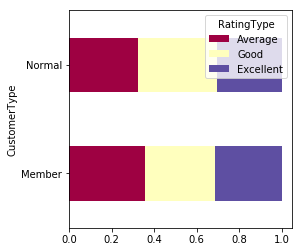

```python
CustomerType_crosstab.div(CustomerType_crosstab.sum(1).astype(float), axis=0).plot(kind="barh", cmap=cmap, stacked=True, figsize=(4,4))
plt.show()
```

```python
Gender_crosstab=pd.crosstab(supermarket_df['Gender'],supermarket_df['RatingType'])
Gender_crosstab
```

| RatingType Gender | Average | Good | Excellent |
| --- | --- | --- | --- |
| Female | 167 | 179 | 155 |
| Male | 174 | 172 | 153 |

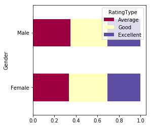

```python
Gender_crosstab.div(Gender_crosstab.sum(1).astype(float), axis=0).plot(kind="barh", cmap=cmap, stacked=True, figsize=(4,4))
plt.show()
```

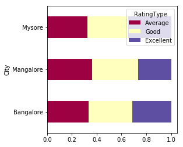

```python
City_crosstab=pd.crosstab(supermarket_df['City'],supermarket_df['RatingType'])
City_crosstab.div(City_crosstab.sum(1).astype(float), axis=0).plot(kind="barh", cmap=cmap, stacked=True, figsize=(4,4))
plt.show()
```

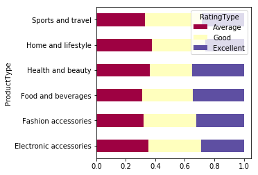

```python
ProductType_crosstab=pd.crosstab(supermarket_df['ProductType'],supermarket_df['RatingType'])
ProductType_crosstab.div(ProductType_crosstab.sum(1).astype(float), axis=0).plot(kind="barh", cmap=cmap, stacked=True, figsize=(4,4))
plt.show()
```

```python
supermarket_df.info()
```

```
<class 'pandas.core.frame.DataFrame'>
RangeIndex: 1000 entries, 0 to 999
Data columns (total 15 columns):
InvoiceID       1000 non-null object
City            1000 non-null object
CustomerType    1000 non-null object
Gender          1000 non-null object
ProductType     1000 non-null object
UnitPrice       1000 non-null float64
Quantity        1000 non-null int64
SellingPrice    1000 non-null float64
PaymentType     1000 non-null object
Date            1000 non-null datetime64[ns]
TimeBin         1000 non-null category
day             1000 non-null int64
month           1000 non-null int64
year            1000 non-null int64
RatingType      1000 non-null category
dtypes: category(2), datetime64[ns](1), float64(2), int64(4), object(6)
memory usage: 103.9+ KB
```

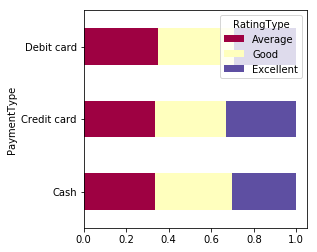

```python
PaymentType_crosstab=pd.crosstab(supermarket_df['PaymentType'],supermarket_df['RatingType'])
PaymentType_crosstab.div(PaymentType_crosstab.sum(1).astype(float), axis=0).plot(kind="barh", cmap=cmap, stacked=True, figsize=(4,4))
plt.show()
```

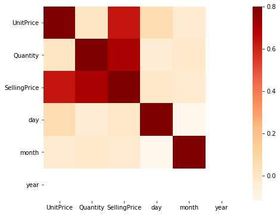

```python
matrix = supermarket_df.corr()
f, ax = plt.subplots(figsize=(9, 6))
sns.heatmap(matrix, vmax=.8, square=True, cmap="OrRd");
```

```python
from scipy import stats
from sklearn.feature_selection import SelectKBest, chi2
```

```python
def check_categorical_dependency (crosstab_table, confidence_interval):
        stat, p, dof,expected = stats.chi2_contingency(crosstab_table)
        print("Chi - Square  Statistic value = {}".format(stat))
        print("P - Value = {}".format(p))
        alpha = 1.0 - confidence_interval
        if p <= alpha:
            print('Dependent (reject H0)')
        else:
            print('Independent (fail to reject H0)')
        return expected
```

```python
exp_table_1 = check_categorical_dependency(City_crosstab, 0.95)
```

```
Chi - Square  Statistic value = 4.607364822765928
P - Value = 0.3300059208189113
Independent (fail to reject H0)
```

```python
pd.DataFrame(exp_table_1)
```

|  | 0 | 1 | 2 |
| --- | --- | --- | --- |
| 0 | 115.940 | 119.340 | 104.720 |
| 1 | 113.212 | 116.532 | 102.256 |
| 2 | 111.848 | 115.128 | 101.024 |

```python
exp_table_2=check_categorical_dependency(ProductType_crosstab, 0.95)
```

```
Chi - Square  Statistic value = 7.2007644754300175
P - Value = 0.7063653556996748
Independent (fail to reject H0)
```

```python
pd.DataFrame(exp_table_2)
```

|  | 0 | 1 | 2 |
| --- | --- | --- | --- |
| 0 | 57.970 | 59.670 | 52.360 |
| 1 | 60.698 | 62.478 | 54.824 |
| 2 | 59.334 | 61.074 | 53.592 |
| 3 | 51.832 | 53.352 | 46.816 |
| 4 | 54.560 | 56.160 | 49.280 |
| 5 | 56.606 | 58.266 | 51.128 |

```python
exp_table_3=check_categorical_dependency(Gender_crosstab, 0.95)
```

```
Chi - Square  Statistic value = 0.2922843363882557
P - Value = 0.8640348561772149
Independent (fail to reject H0)
```

```python
pd.DataFrame(exp_table_3)
```

|  | 0 | 1 | 2 |
| --- | --- | --- | --- |
| 0 | 170.841 | 175.851 | 154.308 |
| 1 | 170.159 | 175.149 | 153.692 |

```python
exp_table_4=check_categorical_dependency(PaymentType_crosstab, 0.95)
```

```
Chi - Square  Statistic value = 1.4166084589813839
P - Value = 0.8413033103118777
Independent (fail to reject H0)
```

```python
pd.DataFrame(exp_table_4)
```

|  | 0 | 1 | 2 |
| --- | --- | --- | --- |
| 0 | 117.304 | 120.744 | 105.952 |
| 1 | 106.051 | 109.161 | 95.788 |
| 2 | 117.645 | 121.095 | 106.260 |

```python
exp_table_5=check_categorical_dependency(CustomerType_crosstab, 0.95)
```

```
Chi - Square  Statistic value = 2.6786673650680446
P - Value = 0.26202019906258867
Independent (fail to reject H0)
```

```python
supermarket_df.head()
```

|  | InvoiceID | City | CustomerType | Gender | ProductType | UnitPrice | Quantity | SellingPrice | PaymentType | Date | TimeBin | day | month | year | RatingType |
| --- | --- | --- | --- | --- | --- | --- | --- | --- | --- | --- | --- | --- | --- | --- | --- |
| 0 | 750-67-8428 | Bangalore | Member | Female | Health and beauty | 74.69 | 7 | 548.9715 | Debit card | 2019-01-05 | Afternoon | 5 | 1 | 2019 | Excellent |
| 1 | 226-31-3081 | Mysore | Normal | Female | Electronic accessories | 15.28 | 5 | 80.2200 | Cash | 2019-03-08 | Morning | 8 | 3 | 2019 | Excellent |
| 2 | 631-41-3108 | Bangalore | Normal | Male | Home and lifestyle | 46.33 | 7 | 340.5255 | Credit card | 2019-03-03 | Afternoon | 3 | 3 | 2019 | Good |
| 3 | 123-19-1176 | Bangalore | Member | Male | Health and beauty | 58.22 | 8 | 489.0480 | Debit card | 2019-01-27 | Evening | 27 | 1 | 2019 | Excellent |
| 4 | 373-73-7910 | Bangalore | Normal | Male | Sports and travel | 86.31 | 7 | 634.3785 | Debit card | 2019-02-08 | Morning | 8 | 2 | 2019 | Average |

```python
supermarket_df = supermarket_df.drop(['InvoiceID', 'UnitPrice','Gender', 'Quantity','Date','TimeBin','PaymentType','month','day','year'], axis=1)
```

```python
supermarket_df.head()
```

|  | City | CustomerType | ProductType | SellingPrice | RatingType |
| --- | --- | --- | --- | --- | --- |
| 0 | Bangalore | Member | Health and beauty | 548.9715 | Excellent |
| 1 | Mysore | Normal | Electronic accessories | 80.2200 | Excellent |
| 2 | Bangalore | Normal | Home and lifestyle | 340.5255 | Good |
| 3 | Bangalore | Member | Health and beauty | 489.0480 | Excellent |
| 4 | Bangalore | Normal | Sports and travel | 634.3785 | Average |

```python
X = supermarket_df.drop('RatingType',1)
y = supermarket_df.RatingType
```

```python
X = pd.get_dummies(X)
supermarket_df = pd.get_dummies(supermarket_df)
```

```python
X.columns
```

```
Index(['SellingPrice', 'City_Bangalore', 'City_Mangalore', 'City_Mysore',
       'CustomerType_Member', 'CustomerType_Normal',
       'ProductType_Electronic accessories', 'ProductType_Fashion accessories',
       'ProductType_Food and beverages', 'ProductType_Health and beauty',
       'ProductType_Home and lifestyle', 'ProductType_Sports and travel'],
      dtype='object')
```

```python
from sklearn.model_selection import train_test_split
X_train, X_test, y_train, y_test = train_test_split(X,y, test_size =0.3)
```

```python
from sklearn.linear_model import LogisticRegression
from sklearn.metrics import accuracy_score
```

```python
model_LR = LogisticRegression(random_state=100)
model_LR.fit(X_train, y_train)
```

```
LogisticRegression(C=1.0, class_weight=None, dual=False, fit_intercept=True,
          intercept_scaling=1, max_iter=100, multi_class='warn',
          n_jobs=None, penalty='l2', random_state=100, solver='warn',
          tol=0.0001, verbose=0, warm_start=False)
```

```python
model_LR.classes_
```

```
array(['Average', 'Excellent', 'Good'], dtype=object)
```

```python
model_LR.coef_
```

```
array([[ 5.65323225e-04, -1.50995605e-01, -5.60508398e-02,
        -1.74810912e-01, -1.58344886e-01, -2.23512470e-01,
        -6.45015007e-03, -1.60164674e-01, -3.92128744e-01,
         1.41024889e-01,  1.22207242e-01, -8.63459199e-02],
       [-1.59558747e-04, -1.11687336e-01, -3.34941873e-01,
         5.89191507e-02, -1.02272866e-01, -2.85437192e-01,
        -3.39595151e-02,  3.23887258e-02,  4.61805828e-02,
         8.59877545e-02, -2.83927859e-01, -2.34379747e-01],
       [-4.90662376e-04, -7.68443242e-02,  2.53655112e-02,
        -2.20743486e-01, -2.65039758e-01, -7.18254171e-03,
        -1.27091869e-01, -3.22894561e-02,  1.80467977e-01,
        -4.20556166e-01, -2.33868865e-02,  1.50634101e-01]])
```

```python
model_LR.intercept_
```

```
array([-0.38185736, -0.38771006, -0.2722223 ])
```

```python
rating_predicted = model_LR.predict(X_test)
```

```python
actual = y_test
```

```python
accuracy_score(actual,rating_predicted)
```

```
0.3233333333333333
```

```python
!pip install pydot
```

```python
from sklearn.tree import DecisionTreeClassifier
from sklearn.metrics import confusion_matrix
from sklearn.tree import export_graphviz
from sklearn.externals.six import StringIO
from IPython.display import Image
from pydot import graph_from_dot_data
```

```python
dt = DecisionTreeClassifier(random_state=100)
dt.fit(X_train, y_train)
```

```
DecisionTreeClassifier(class_weight=None, criterion='gini', max_depth=None,
            max_features=None, max_leaf_nodes=None,
            min_impurity_decrease=0.0, min_impurity_split=None,
            min_samples_leaf=1, min_samples_split=2,
            min_weight_fraction_leaf=0.0, presort=False, random_state=100,
            splitter='best')
```

```python
supermarket_df.columns
```

```
Index(['SellingPrice', 'City_Bangalore', 'City_Mangalore', 'City_Mysore',
       'CustomerType_Member', 'CustomerType_Normal',
       'ProductType_Electronic accessories', 'ProductType_Fashion accessories',
       'ProductType_Food and beverages', 'ProductType_Health and beauty',
       'ProductType_Home and lifestyle', 'ProductType_Sports and travel',
       'RatingType_Average', 'RatingType_Good', 'RatingType_Excellent'],
      dtype='object')
```

```python
feature_names = supermarket_df.columns[0: supermarket_df.columns.size-3]
feature_names
```

```
Index(['SellingPrice', 'City_Bangalore', 'City_Mangalore', 'City_Mysore',
       'CustomerType_Member', 'CustomerType_Normal',
       'ProductType_Electronic accessories', 'ProductType_Fashion accessories',
       'ProductType_Food and beverages', 'ProductType_Health and beauty',
       'ProductType_Home and lifestyle', 'ProductType_Sports and travel'],
      dtype='object')
```

```python
target_names = supermarket_df.columns[supermarket_df.columns.size - 3:]
target_names
```

```
Index(['RatingType_Average', 'RatingType_Good', 'RatingType_Excellent'], dtype='object')
```

```python
# !pip install pydotplus
```

```python
from sklearn.externals.six import StringIO
from IPython.display import Image
from sklearn import tree
from sklearn.tree import export_graphviz
import pydotplus
dot_data = StringIO()
export_graphviz(dt, out_file=dot_data, feature_names=feature_names, class_names=target_names,
                filled=True, rounded=True,
                special_characters=True)
```

```python
# conda install graphviz
```

```python
#graph = pydotplus.graph_from_dot_data(dot_data.getvalue())
#Image(graph.create_png())
```